# Application of machine learning methods for claim prediction in car insurance data

Barbara Gendron-Audebert

December 27th, 2022

# Preliminary imports and data preparation

```r
library(caret)
library(corrplot)
library(cowplot)
library(data.table)
library(ggplot2)
library(gridExtra)
library(mlr)
library(mltools)
library(randomForest)
library(rpart)
library(rpart.plot)
library(tidyverse)
library(xgboost)
```

Now, we can import data and start dealing with feature formats so these are relevant regarding the represented quantities.

```r
data <- read.table("Car_Insurance_Claim.csv", header=T, sep=',')
data = data%>%mutate_if(is.character, as.factor)
data$VEHICLE_OWNERSHIP = as.factor(data$VEHICLE_OWNERSHIP)
data$MARRIED = as.factor(data$MARRIED)
data$CHILDREN = as.factor(data$CHILDREN)
data$OUTCOME = as.factor(data$OUTCOME)
data <- na.omit(data)
summary(data)
```

```
##        ID            AGE          GENDER           RACE      DRIVING_EXPERIENCE
##  Min.   :   101   16-25:1621   female:4084   majority:7323   0-9y  :2864
##  1st Qu.:247706   26-39:2475   male  :4065   minority: 826   10-19y:2662
##  Median :503269   40-64:2412                                 20-29y:1756
##  Mean   :501340   65+  :1641                                 30y+  : 867
##  3rd Qu.:756207
##  Max.   :999976
##        EDUCATION              INCOME      CREDIT_SCORE     VEHICLE_OWNERSHIP
##  high school:3404   middle class :1727   Min.   :0.05336   0:2451
##  none       :1528   poverty      :1459   1st Qu.:0.41789   1:5698
##  university :3217   upper class  :3588   Median :0.52676
##                     working class:1375   Mean   :0.51637
##                                          3rd Qu.:0.62007
##                                          Max.   :0.96082
##       VEHICLE_YEAR  MARRIED  CHILDREN  POSTAL_CODE    ANNUAL_MILEAGE
##  after 2015 :2507   0:4066   0:2532   Min.   :10238   Min.   : 2000
##  before 2015:5642   1:4083   1:5617   1st Qu.:10238   1st Qu.:10000
##                                       Median :10238   Median :12000
##                                       Mean   :19726   Mean   :11693
##                                       3rd Qu.:32765   3rd Qu.:14000
##                                       Max.   :92101   Max.   :22000
##      VEHICLE_TYPE  SPEEDING_VIOLATIONS      DUIS        PAST_ACCIDENTS
##  sedan     :7761   Min.   : 0.000      Min.   :0.0000   Min.   : 0.000
##  sports car: 388   1st Qu.: 0.000      1st Qu.:0.0000   1st Qu.: 0.000
##                    Median : 0.000      Median :0.0000   Median : 0.000
##                    Mean   : 1.486      Mean   :0.2408   Mean   : 1.066
##                    3rd Qu.: 2.000      3rd Qu.:0.0000   3rd Qu.: 2.000
##                    Max.   :22.000      Max.   :6.0000   Max.   :15.000
##  OUTCOME
##  0:5613
##  1:2536
##
##
##
##
```

# Exploratory data analysis

## Numerical features

### Histograms

This next cell plot the distribution of each numerical variable using histograms.

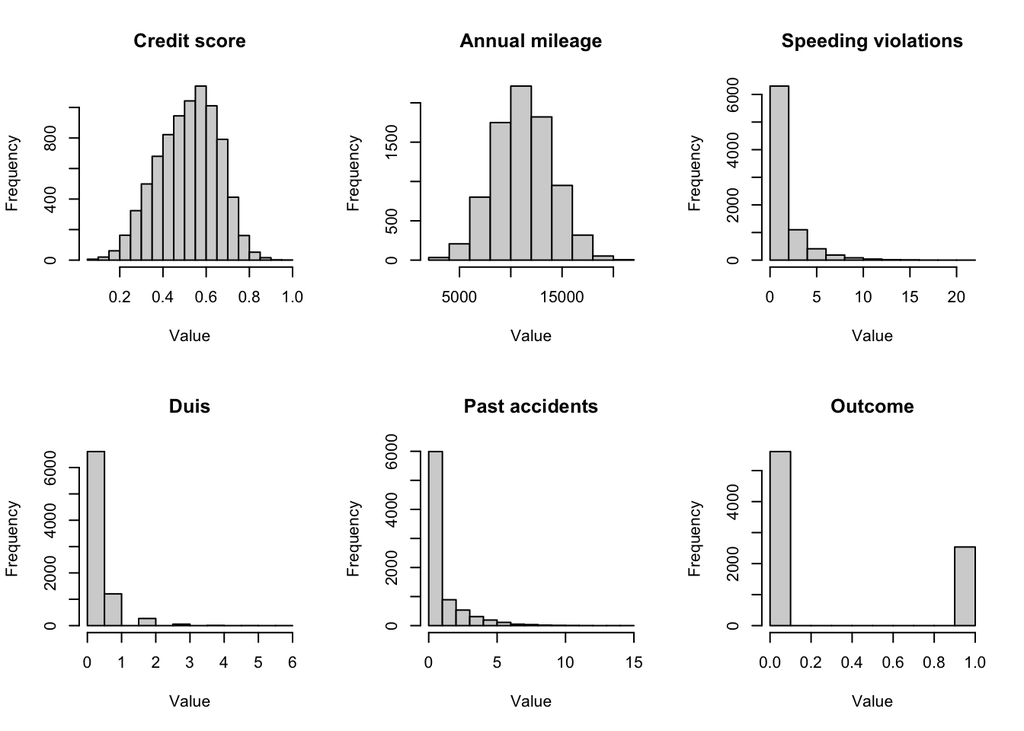

```r
# separate plot space in 2x3 blocks
op <- par(mfrow=c(2,3))

# plot histograms
hist(data$CREDIT_SCORE, main="Credit score", xlab="Value")
hist(data$ANNUAL_MILEAGE, main="Annual mileage", xlab="Value")
hist(data$SPEEDING_VIOLATIONS, main = "Speeding violations", xlab="Value")
hist(data$DUIS, main="Duis", xlab="Value")
hist(data$PAST_ACCIDENTS, main="Past accidents", xlab="Value")
hist(as.numeric(levels(data$OUTCOME))[data$OUTCOME], main = "Outcome", xlab="Value")
```

### Violin plots

Now, we observe the data distribution of numerical features regarding the outcome value. For this, I use violin plots which is a more detailed version of boxplots that gives the precise distribution of the samples.

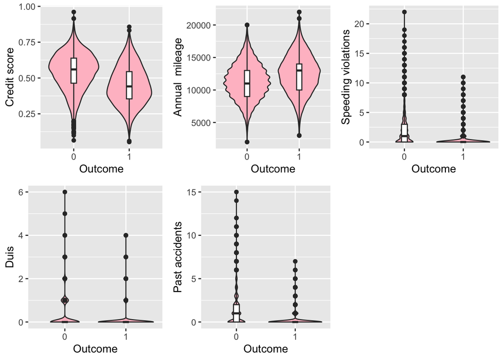

```r
cs <- ggplot(data, aes(as.factor(OUTCOME), CREDIT_SCORE)) + geom_violin(fill="pink") + geom_boxplot(width=0.1) + labs(x="Outcome", y="Credit score")
am <- ggplot(data, aes(as.factor(OUTCOME), ANNUAL_MILEAGE)) + geom_violin(fill="pink") + geom_boxplot(width=0.1) + labs(x="Outcome", y="Annual  mileage")
sv <- ggplot(data, aes(as.factor(OUTCOME), SPEEDING_VIOLATIONS)) + geom_violin(fill="pink") + geom_boxplot(width=0.1) + labs(x="Outcome", y="Speeding violations")
du <- ggplot(data, aes(as.factor(OUTCOME), DUIS)) + geom_violin(fill="pink") + geom_boxplot(width=0.1) + labs(x="Outcome", y="Duis")
pa <- ggplot(data, aes(as.factor(OUTCOME), PAST_ACCIDENTS)) + geom_violin(fill="pink") + geom_boxplot(width=0.1) + labs(x="Outcome", y="Past accidents")
grid.arrange(cs, am, sv, du, pa, ncol=3, nrow=2)
```

## Categorical features

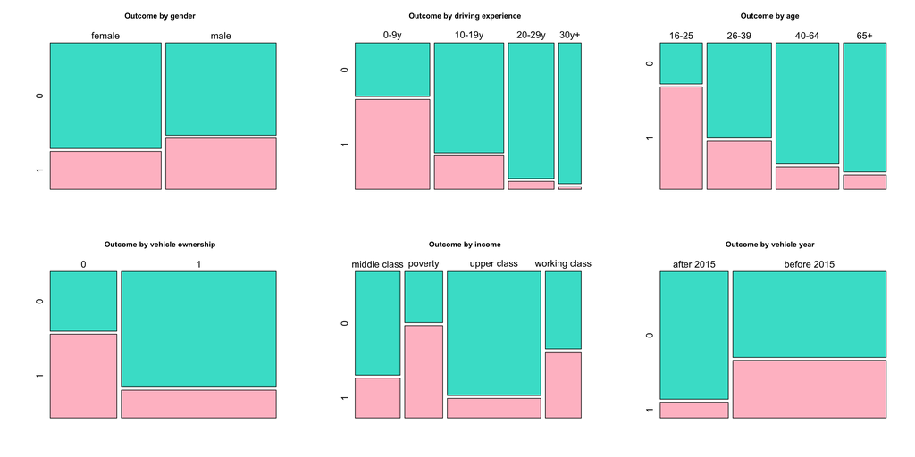

```r
op <- par(mfrow=c(2,3))
ge <- table(data$GENDER, data$OUTCOME)
plot(ge, main="Outcome by gender", col=c('turquoise', 'pink'), cex=1.5)
de <- table(data$DRIVING_EXPERIENCE, data$OUTCOME)
plot(de, main="Outcome by driving experience",col=c('turquoise', 'pink'), cex=1.5)
ag <- table(data$AGE, data$OUTCOME)
plot(ag, main="Outcome by age", col=c('turquoise', 'pink'), cex=1.5)
vo <- table(data$VEHICLE_OWNERSHIP, data$OUTCOME)
plot(vo, main="Outcome by vehicle ownership", col=c('turquoise', 'pink'), cex=1.5)
ic <- table(data$INCOME, data$OUTCOME)
plot(ic, main="Outcome by income", col=c('turquoise', 'pink'), cex=1.5)
vy <- table(data$VEHICLE_YEAR, data$OUTCOME)
plot(vy, main="Outcome by vehicle year", col=c('turquoise', 'pink'), cex=1.5)
```

# Feature engineering

The aim of this step is to identify correlated features, and features that are the most correlated to the outcome in order to perform feature selection. Let’s first have a look at the overall correlations between numerical features using `corrplot()`.

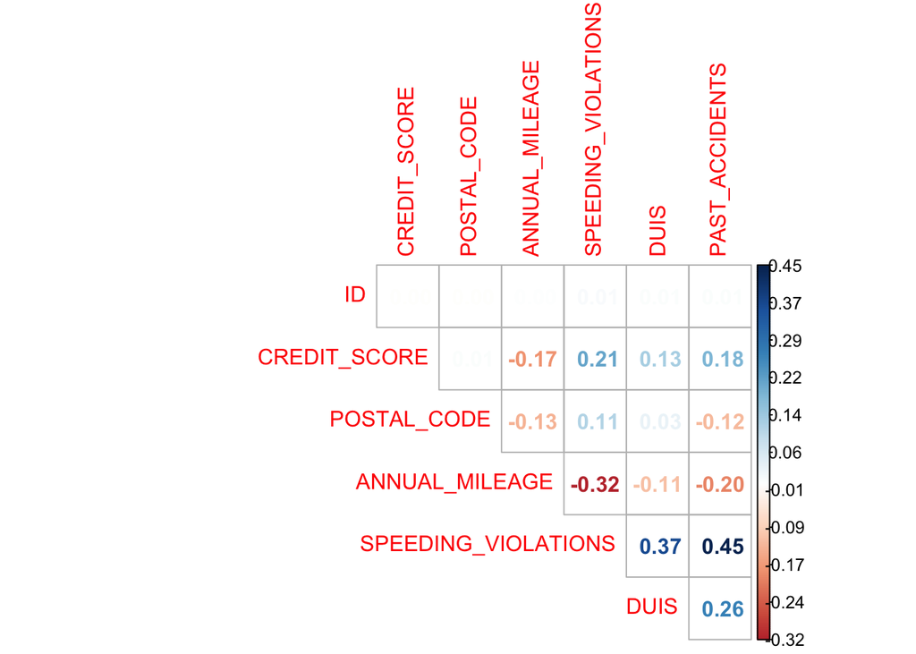

```r
# filter for numeric data
num_data <- data %>% select(where(is.numeric))

# save the corrplot in a pdf file
corrplot(cor(num_data), type = "upper", is.corr = FALSE, method = "number", outline = TRUE, diag = FALSE)
```

Now, let’s have a look at the correlations of all the variables with the variable `OUTCOME`. The first step is the perform one-hot encoding on categorical features. Afterwards, it is possible to compute the correlation matrix and select the column (or line, the matrix is symmetric) corresponding to the `OUTCOME` variable. Then, converting this column to a data frame, it is possible to display the correlation values by decreasing order of their absolute value. This way, the higher is the feature in the list, the more correlated to `OUTCOME`.

```r
# Compute the list of correlation values
newdata <- one_hot(as.data.table(data))
mat <- cor(newdata)
correlations <- as.data.frame(mat[,37])
names(correlations) <- c("Outcome")
correlations <- correlations %>% arrange(desc(abs(Outcome)))
```

```r
# Display all variables which correlation with OUTCOME is more than 20%
select <- correlations %>%
              filter(abs(Outcome)>0.2 & abs(Outcome) != 1)
select
```

```
##                              Outcome
## DRIVING_EXPERIENCE_0-9y   -0.5022658
## AGE_16-25                 -0.4339322
## VEHICLE_OWNERSHIP_0       -0.3862170
## VEHICLE_OWNERSHIP_1        0.3862170
## INCOME_upper class         0.3361555
## INCOME_poverty            -0.3345763
## CREDIT_SCORE               0.3214357
## PAST_ACCIDENTS             0.3127380
## SPEEDING_VIOLATIONS        0.2931377
## VEHICLE_YEAR_after 2015    0.2901292
## VEHICLE_YEAR_before 2015  -0.2901292
## DRIVING_EXPERIENCE_20-29y  0.2891044
## MARRIED_0                 -0.2532003
## MARRIED_1                  0.2532003
## CHILDREN_0                -0.2302548
## CHILDREN_1                 0.2302548
## AGE_65+                    0.2284732
## DRIVING_EXPERIENCE_30y+    0.2181787
## AGE_40-64                  0.2163573
```

```r
data_processed <- data[,!names(data) %in% c('GENDER', 'POSTAL_CODE', 'EDUCATION', 'RACE', 'ID', 'VEHICLE_TYPE')]
summary(data_processed)
```

```
##     AGE       DRIVING_EXPERIENCE           INCOME      CREDIT_SCORE
##  16-25:1621   0-9y  :2864        middle class :1727   Min.   :0.05336
##  26-39:2475   10-19y:2662        poverty      :1459   1st Qu.:0.41789
##  40-64:2412   20-29y:1756        upper class  :3588   Median :0.52676
##  65+  :1641   30y+  : 867        working class:1375   Mean   :0.51637
##                                                       3rd Qu.:0.62007
##                                                       Max.   :0.96082
##  VEHICLE_OWNERSHIP      VEHICLE_YEAR  MARRIED  CHILDREN ANNUAL_MILEAGE
##  0:2451            after 2015 :2507   0:4066   0:2532   Min.   : 2000
##  1:5698            before 2015:5642   1:4083   1:5617   1st Qu.:10000
##                                                         Median :12000
##                                                         Mean   :11693
##                                                         3rd Qu.:14000
##                                                         Max.   :22000
##  SPEEDING_VIOLATIONS      DUIS        PAST_ACCIDENTS   OUTCOME
##  Min.   : 0.000      Min.   :0.0000   Min.   : 0.000   0:5613
##  1st Qu.: 0.000      1st Qu.:0.0000   1st Qu.: 0.000   1:2536
##  Median : 0.000      Median :0.0000   Median : 0.000
##  Mean   : 1.486      Mean   :0.2408   Mean   : 1.066
##  3rd Qu.: 2.000      3rd Qu.:0.0000   3rd Qu.: 2.000
##  Max.   :22.000      Max.   :6.0000   Max.   :15.000
```

# Machine learning models

## Prepare data for model training and evaluation

The next cell processes the train/test split, keeping 20% of the processed dataset for testing.

```r
set.seed(42) # set random seed for reproducibility

# Train/test split
trainIndex = sample(1:nrow(data_processed), size = round(0.8*nrow(data_processed)), replace=FALSE)
train = data_processed[trainIndex ,]
test = data_processed[-trainIndex ,]
```

## Models

### 1) Logistic regression

```r
# Train the model
logreg <- glm(OUTCOME~., data=train, family=binomial)

# Compute the predictions
proba_logreg <- predict(logreg, newdata=test, type="response")
pred_logreg <- ifelse(proba_logreg<0.5, 0, 1)
pred_logreg <- factor(pred_logreg)

# Store the confusion matrix and other metrics
MC_logreg <- confusionMatrix(as.factor(test$OUTCOME), pred_logreg)
```

### 2) Decision Tree Classifier

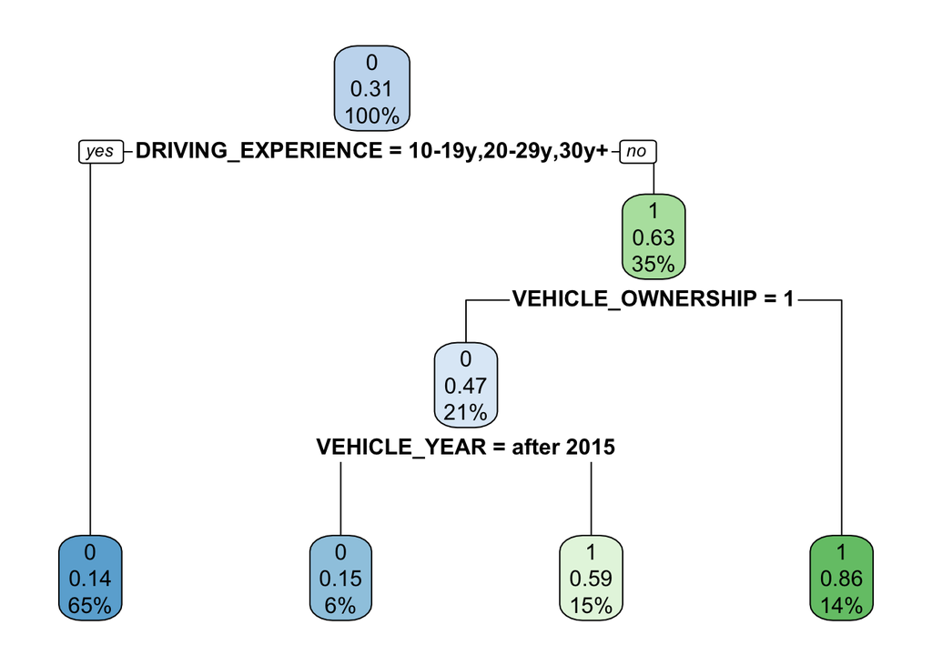

```r
# Train the model
decision_tree <- rpart(OUTCOME~., data=train)
rpart.plot(decision_tree)
```

```r
# Compute the predictions
pred_tree <- predict(object=decision_tree, newdata=test, type="class")

# Store the confusion matrix and other metrics
MC_tree <- confusionMatrix(test$OUTCOME, pred_tree)
```

### 3) Random Forest Classifier

```r
# Train the model
rf <- randomForest(as.factor(OUTCOME)~., data=train, proximity=TRUE)

# Compute the predictions
pred_rf <- predict(rf, test)

# Store the confusion matrix and other metrics
MC_rf <- confusionMatrix(test$OUTCOME, pred_rf)
```

### 4) XGBoost model

For this part, the following code is inspired of https://www.kaggle.com/code/ihorhetman/xgboost-model-for-car-insurance-prediction.

To use this model, some more preprocessing is required. First, it is necessary to convert `OUTCOME` to numeric values in train and test set

```r
train$OUTCOME = as.numeric(levels(train$OUTCOME))[train$OUTCOME]
test$OUTCOME = as.numeric(levels(test$OUTCOME))[test$OUTCOME]
```

Then, another requirement is to convert train and test set to matrix. Here, it is important to not include the `OUTCOME` variable, because it will be stored in another variable that indicates the labels.

```r
X_train <- model.matrix(~ INCOME + VEHICLE_YEAR +
                    SPEEDING_VIOLATIONS  + AGE + DRIVING_EXPERIENCE +
                    CREDIT_SCORE + MARRIED + ANNUAL_MILEAGE + DUIS +
                    VEHICLE_OWNERSHIP + CHILDREN +
                    PAST_ACCIDENTS,data=train)

X_test <- model.matrix(~ INCOME + VEHICLE_YEAR +
                          SPEEDING_VIOLATIONS  + AGE + DRIVING_EXPERIENCE +
                          CREDIT_SCORE + MARRIED + ANNUAL_MILEAGE + DUIS +
                          VEHICLE_OWNERSHIP + CHILDREN +
                          PAST_ACCIDENTS,data=test)
```

Finally, it is time to process the labels and the datasets to perform some cross-validation. After this step, the XGBoost model is ready to be trained efficiently.

```r
labels <- train$OUTCOME
ts_label <- test$OUTCOME

dtrain <- xgb.DMatrix(data = X_train, label = labels)
dtest <- xgb.DMatrix(data = X_test, label=ts_label)

xgbcv <- xgb.cv(data = dtrain, nrounds = 100,
                nfold = 5, showsd = T, stratified = T,
                print_every_n = 10, early_stopping_rounds = 20,
                maximize = F)
```

[output not shown]

Let’s train the XGBoost model and evaluate it on the test set in order to display evaluation metrics:

```r
# Train the model
xgb1 = xgb.train(data = dtrain,
                 max.depth = 2,
                 eta = 1,
                 nthread = 2,
                 nrounds = 10,
                 objective = "binary:logistic",
                 verbose = 1)

# Compute the predictions
xgbpred1 <- predict(xgb1,dtest)
xgbpred_res1 <- as.numeric(xgbpred1 > 0.5,1,0)

# Store the confusion matrix and other metrics
MC_xgb = confusionMatrix(as.factor(xgbpred_res1), as.factor(ts_label))
MC_xgb
```

```
## Confusion Matrix and Statistics
##
##           Reference
## Prediction    0    1
##          0 1022  160
##          1  108  340
##
##                Accuracy : 0.8356
##                  95% CI : (0.8167, 0.8533)
##     No Information Rate : 0.6933
##     P-Value [Acc > NIR] : < 2.2e-16
##
##                   Kappa : 0.6019
##
##  Mcnemar's Test P-Value : 0.001837
##
##             Sensitivity : 0.9044
##             Specificity : 0.6800
##          Pos Pred Value : 0.8646
##          Neg Pred Value : 0.7589
##              Prevalence : 0.6933
##          Detection Rate : 0.6270
##    Detection Prevalence : 0.7252
##       Balanced Accuracy : 0.7922
##
##        'Positive' Class : 0
##
```

In addition to previous results, I provide here the feature importances.

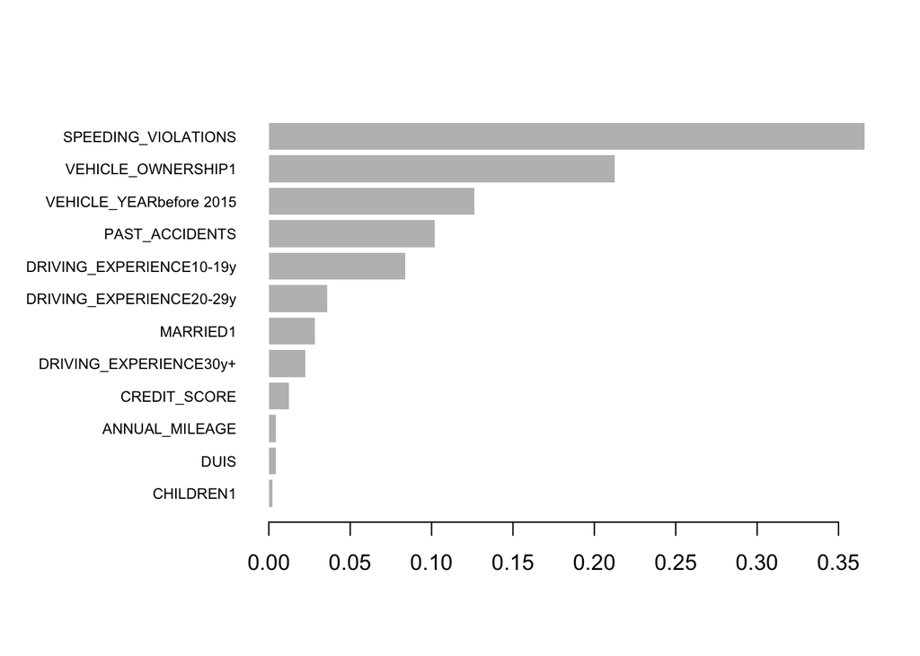

```r
mat <- xgb.importance (feature_names = colnames(X_train), model = xgb1)
xgb.plot.importance (importance_matrix = mat)
```